# Pittsburgh Crime Data

Conor Tompkins

2017-10-07

*Note: this analysis was performed in February 2017 using a contemporary dataset.*

## Exploratory Analysis

The [Western Pennsylvania Regional Data Center](http://www.wprdc.org/) is a great resource for data about Pittsburgh

They have published an archive of police incident data from 2005-2015

You can download the data here: https://data.wprdc.org/dataset/uniform-crime-reporting-data

We will be using the following R packages for this analysis

- tidyverse
- lubridate
- viridis
- ggmap

Install these packages using the following code

```r
install.packages(c("tidyverse", "lubridate", "viridis", "ggmap"))
```

Then load the packages

```r
library(tidyverse)
library(lubridate)
library(viridis)
library(ggmap)
```

[Set your working directory](http://rprogramming.net/set-working-directory-in-r/)

Then, read the data into R

```r
df <- read_csv("https://raw.githubusercontent.com/conorotompkins/pgh-crime/master/archive-police-blotter.csv")
```

Next, we will change the column names so they are easier to work with

```r
colnames(df) <- tolower(colnames(df))
```

Then, rename the column names

```r
df <- df %>%
  rename(date_time = incidenttime,
         location = incidentlocation,
         cleared_flag = clearedflag,
         neighborhood = incidentneighborhood,
         zone = incidentzone,
         description = hierarchydesc,
         tract = incidenttract)
```

Next, we will use lubridate to change the relevant columns to dates and times

```r
df <- df %>%
  mutate(date_time = mdy_hm(date_time),
         date = ymd(substr(date_time, 1, 10)),
         year = year(date),
         month = month(date, label = TRUE),
         wday = wday(date, label = TRUE),
         mday = mday(date))
```

Now we will reorder the columns and select the ones we want to work with

```r
df <- df %>%
  select(date,
         year,
         month,
         wday,
         mday,
         location,
         neighborhood,
         zone,
         description,
         cleared_flag,
         x,
         y)
```

Let’s see how the data look now

```r
glimpse(df)
```

```
## Observations: 495,251
## Variables: 12
## $ date         <date> 2005-01-01, 2005-01-03, 2005-01-03, 2005-01-05, ...
## $ year         <dbl> 2005, 2005, 2005, 2005, 2005, 2005, 2005, 2005, 2...
## $ month        <ord> Jan, Jan, Jan, Jan, Jan, Mar, Mar, Mar, Mar, Mar,...
## $ wday         <ord> Sat, Mon, Mon, Wed, Wed, Wed, Wed, Wed, Wed, Wed,...
## $ mday         <int> 1, 3, 3, 5, 5, 2, 2, 2, 2, 2, 2, 2, 2, 4, 8, 5, 3...
## $ location     <chr> "5400 Block NORTHUMBERLAND ST PITTSBURGH, PA", "P...
## $ neighborhood <chr> "Squirrel Hill North", "Squirrel Hill North", "Sq...
## $ zone         <chr> "4", "4", "3", "1", "4", "2", "5", "1", "2", "1",...
## $ description  <chr> "MOTOR THEFT (OTHER)-PLATE ONLY", "MTR VEH THEFT ...
## $ cleared_flag <chr> "N", "N", "N", "N", "N", "Y", "N", "N", "Y", "N",...
## $ x            <dbl> -79.93403, 0.00000, 0.00000, -80.02433, 0.00000, ...
## $ y            <dbl> 40.43887, 0.00000, 0.00000, 40.46254, 0.00000, 40...
```

Which zone has the most incidents?

```r
df %>%
  group_by(zone) %>%
  count() %>%
  arrange(-n)
```

```
## # A tibble: 16 x 2
## # Groups:   zone [16]
##         zone      n
##        <chr>  <int>
##  1         3 121018
##  2         5  90976
##  3         1  85195
##  4         2  80782
##  5         4  78313
##  6         6  35425
##  7   OUTSIDE   2125
##  8       OSC   1390
##  9         9     11
## 10      <NA>      5
## 11      SAFC      3
## 12       TRU      3
## 13       SDD      2
## 14      HAPD      1
## 15 NARC/VICE      1
## 16  PROPROOM      1
```

Before we start making plots, we will load my custom theme

```r
theme_set(theme_bw())
```

How has the number of incidents changed over time?

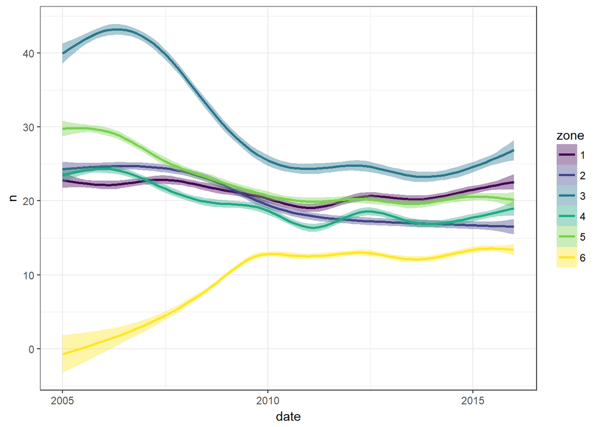

```r
df %>%
  filter(zone %in% c(1:6)) %>%
  group_by(zone, date) %>%
  count() %>%
  ggplot(aes(date, n, color = zone, fill = zone)) +
  geom_smooth() +
  scale_fill_viridis(discrete = TRUE) +
  scale_color_viridis(discrete = TRUE)
```

Looks like there is a data or reporting problem in Zone 6

Bob Gradeck pointed out that [Zone 6 was closed in 2003 and reopened in 2008](http://www.post-gazette.com/local/neighborhoods/2008/03/31/Police-manpower-tipped-to-West-End-s-Zone-6/stories/200803310145)

What does the trend look like if we just look at incidents since 2008?

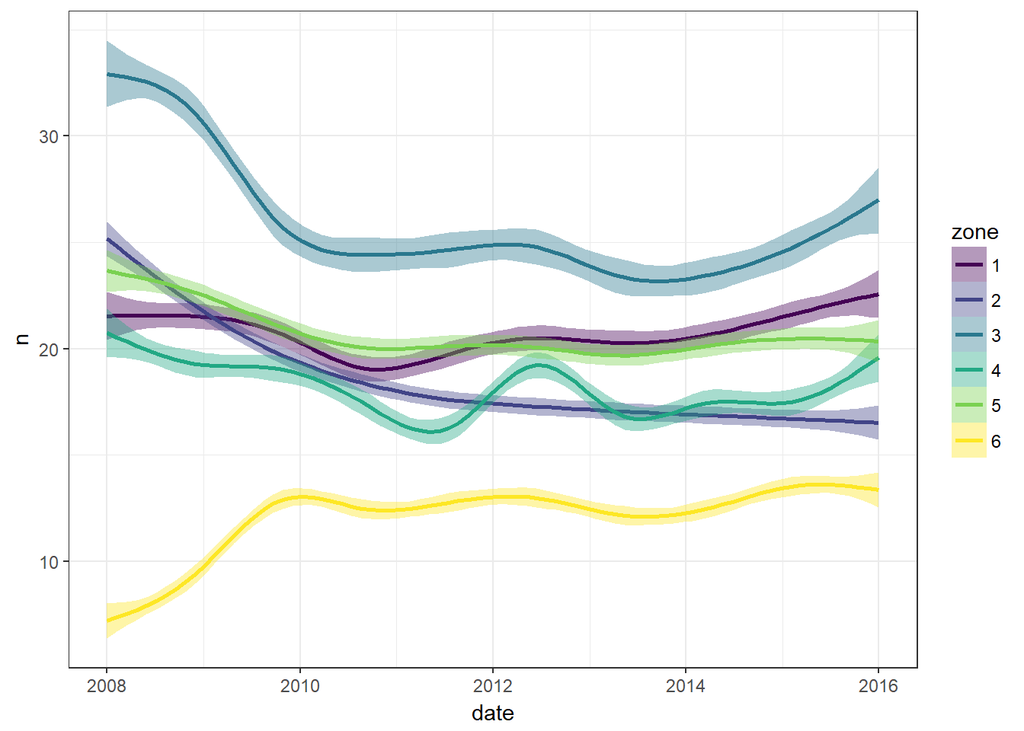

```r
df %>%
  filter(zone %in% c(1:6), year >= 2008) %>%
  group_by(zone, date) %>%
  count() %>%
  ggplot(aes(date, n, color = zone, fill = zone)) +
  geom_smooth() +
  scale_fill_viridis(discrete = TRUE) +
  scale_color_viridis(discrete = TRUE)
```

Which neighborhood has the most incidents?

```r
df %>%
  group_by(neighborhood) %>%
  count() %>%
  arrange(-n)
```

```
## # A tibble: 95 x 2
## # Groups:   neighborhood [95]
##                   neighborhood     n
##                          <chr> <int>
##  1 Golden Triangle/Civic Arena 29147
##  2            South Side Flats 28251
##  3                     Carrick 18059
##  4                  Bloomfield 16223
##  5                   Shadyside 14584
##  6                East Liberty 11903
##  7                   Knoxville 11276
##  8              Homewood South 11019
##  9            Mount Washington 11018
## 10             Central Oakland 10435
## # ... with 85 more rows
```

Which incident descriptions are the most common?

```r
df %>%
  group_by(description) %>%
  count() %>%
  arrange(-n)
```

```
## # A tibble: 330 x 2
## # Groups:   description [330]
##                       description      n
##                             <chr>  <int>
##  1                           <NA> 109346
##  2                THEFT FROM AUTO  29617
##  3               THEFT/ALL OTHERS  28790
##  4       CRIMINAL MISCHIEF (AUTO)  28143
##  5          SIMPLE ASSAULT/INJURY  22188
##  6              CRIMINAL MISCHIEF  19635
##  7 HARRASSMENT/THREAT/ATTEMPT/PHY  16988
##  8         BURGLARY/FORCE ENT/RES  15171
##  9           MTR VEH THEFT (AUTO)  12313
## 10              MARIJUANA-POSSESS  11666
## # ... with 320 more rows
```

Looks like there are many NA values

Have the number of marijuana-related incidents changed over time?

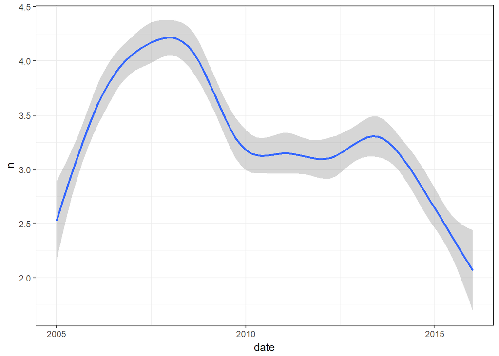

```r
pot_incidents <- df %>%
  filter(grepl("MARIJUANA", description) == TRUE) %>%
  group_by(date) %>%
  count()

#Plot the data
ggplot(data = pot_incidents, aes(x = date, y = n)) +
  geom_smooth()
```

Let’s look at how the data looks on a map

First, create the map

```r
city_map <-  get_map(location = "Oakland, Pittsburgh, PA",
               zoom = 12,
               maptype = "toner",
               source = "stamen",
               messaging = FALSE)
```

View the map to make sure it looks right

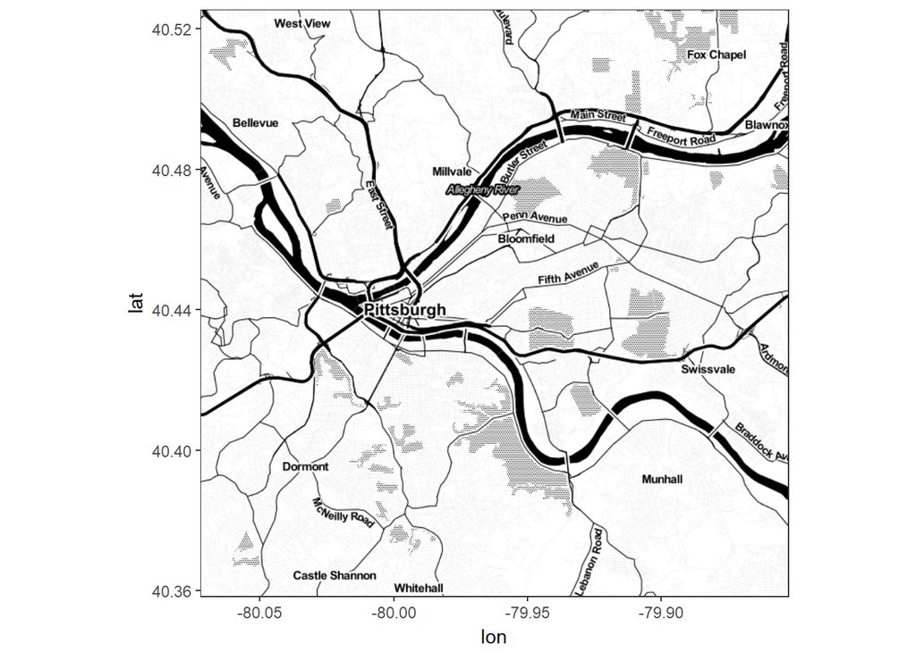

```r
ggmap(city_map)
```

Filter out data that is not in one of the six police zones

```r
df_map <- df %>%
  filter(zone %in% c(1:6))
```

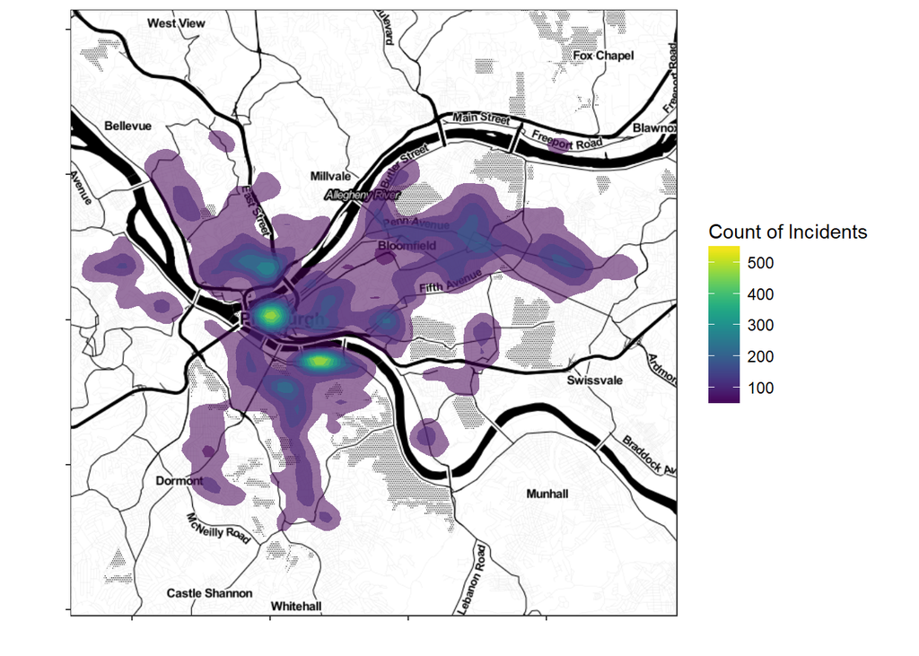

```r
ggmap(city_map) +
  stat_density_2d(data = df_map, #Using a 2d contour
                  aes(x, #longitude
                      y, #latitude
                      fill = ..level.., #Use the count of incidents as the fill
                      alpha = .5), #Use alpha so you can see the map under the data
                  geom = "polygon") + #We want the contour in a polygon
  scale_fill_viridis() +
  guides(alpha = FALSE,
         fill = guide_colorbar("Count of Incidents")) +
  labs(x = "",
       y = "") +
  theme(axis.text = element_blank())
```